[O’Hara on GitHub](https://github.com/oharac)

# Rasterize EEZs, MEOWs, and Bathymetry to Mollweide

Compiled on Wed Jan 8 21:22:28 2020 by ohara

```r
library(raster)
library(sf)
library(fasterize)

source('https://raw.githubusercontent.com/oharac/src/master/R/common.R')

source(here('common_fxns.R'))
source(here('spatial_fxns.R'))
```

# 1 Summary

# 2 Data Sources

- Marine Ecoregions of the World: Spalding, M. D., Fox, H. E., Allen, G. R., Davidson, N., Ferdaña, Z. A., Finlayson, M. A. X., … others. (2007). Marine ecoregions of the world: A bioregionalization of coastal and shelf areas. BioScience, 57(7), 573–583.
- Bathymetry (GEBCO): Sandwell, D. T., Gille, S. T., & Smith, W. H. F. (2002, June). Bathymetry from Space:Oceanography, Geophysics, and Climate. Retrieved from https://www.gebco.net/

# 3 Methods

## 3.1 EEZ raster

Using the OHI global EEZ shapefile, we will include all EEZs by OHI region code, as well as FAO regions and Antarctica, using unique identifiers. This will allow for separation by high seas vs. EEZ, or different takes on IUCN regional assessments using FAO or EEZ identifiers.

EEZ is rasterized for both land and sea, and then clipped to cells with non-NA values in the ocean_area raster. This ensures presence of more coastal cells with fractional ocean area coverage.

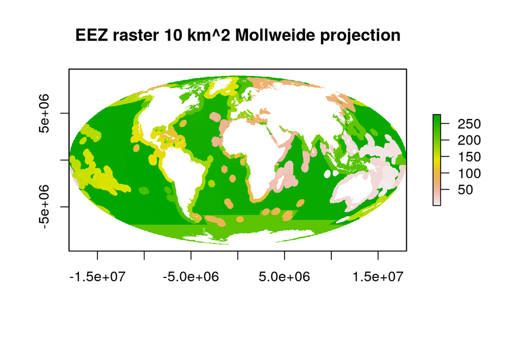

## 3.2 MEOW raster

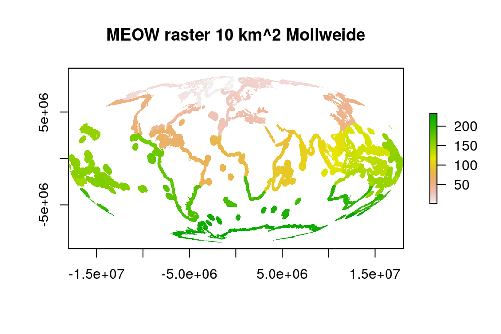

## 3.3 Bathymetry raster

Using [General Bathymetric Chart of the Oceans (GEBCO) bathymetry raster](https://www.bodc.ac.uk/data/hosted_data_systems/gebco_gridded_bathymetry_data/), identify min depth of ocean cells. For neritic and coastal cells, leaving as min depth allows for changing depth thresholds if desired. We will not clip based on anything below 200 m, so can classify these more coarsely.

Bathymetry is masked to the ocean area raster.

### 3.3.1 Create and view minimum depth raster

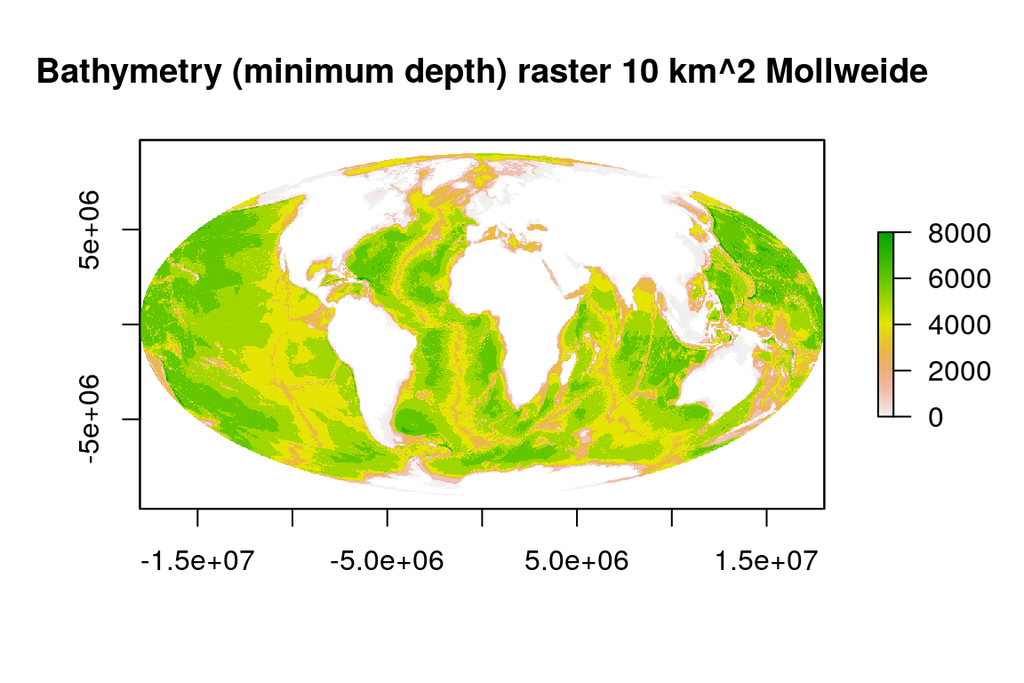